# Part_ii_Regression_c

Yijun Zhou

4/26/2022

## load packages

```r
library(tidyverse)
library(caret)
```

```r
library(coefplot)
library(rstanarm)
```

## read data set

```r
df_all <- readr::read_csv("final_project_train.csv", col_names = TRUE)
df_all<-df_all %>%mutate(log_response=log(response))%>%
  select(-rowid,-outcome,-response)%>%glimpse()
```

```
## Rows: 677
## Columns: 36
## $ region       <chr> "XX", "XX", "XX", "XX", "XX", "XX", "XX", "XX", "XX", "XX…
## $ customer     <chr> "B", "B", "B", "B", "B", "B", "B", "B", "B", "B", "B", "B…
## $ xb_01        <dbl> 4.000000, 1.000000, 2.000000, 2.520000, 2.548387, 3.07142…
## $ xb_02        <dbl> 4, 1, 2, 11, 6, 6, 10, 12, 9, 10, 8, 10, 10, 8, 6, 10, 13…
## $ xb_03        <dbl> 4, 1, 2, -6, -1, 1, -4, -4, -2, -4, -2, -2, -2, -4, 1, -4…
## $ xn_01        <dbl> 3.0000000, 2.0000000, 2.0000000, 1.5333333, 0.8387097, 1.…
## $ xn_02        <dbl> 3, 2, 4, 9, 3, 8, 6, 10, 10, 4, 6, 8, 9, 5, 7, 12, 12, 6,…
## $ xn_03        <dbl> 3, 2, 0, -3, -4, -2, -5, -6, -3, -5, -3, -6, -4, -3, 0, -…
## $ xa_01        <dbl> 12.000000, 3.000000, 9.000000, 7.080000, 6.451613, 6.8571…
## $ xa_02        <dbl> 12, 3, 9, 29, 17, 18, 24, 27, 20, 19, 15, 24, 24, 15, 14,…
## $ xa_03        <dbl> 12, 3, 9, -7, -2, 2, -9, -5, -3, -3, -1, 1, -2, -3, 3, -4…
## $ xb_04        <dbl> 1.3333333, 1.0000000, 1.0000000, 0.8950476, 1.2247312, 1.…
## $ xb_05        <dbl> 1.3333333, 1.0000000, 1.0000000, -2.0000000, -0.5000000, …
```

[output cut: 23 more lines]

# overview of iiC

The aim of this part is making predictions with your 2 selected linear models in order to visualize the trends of the log-transformed response with respect to the inputs, using non-Bayesian or Bayesian models for the predictions.  
1) Decide which inputs/features you wish to visualize the trends with respect to  
2) Visualize the predictive trends using the following style:  
The primary input should be used as the x-aesthetic in a graphic  
The secondary input should be used as a facet variable-it is recommended to use 4 to 6 unique values if your secondary input is a continuous variable  
you must decide what values to use for the remaining inputs  
3) You must include the predictive mean trend, the confidence interval, and the prdiction interval whether you use non-Bayesian or Bayesian models.  
4) You must state if the predictive trends are consistent between the 2 selected linear models.

## 1) decide which inputs you wish to visualize the trends with respect to

the models I selected is model_lm_3 and model_lm_8. ### for model_3

```r
fit_lm_3 <-lm(log_response~.,data=df_all)
fit_lm_3 %>%summary()
```

```
##
## Call:
## lm(formula = log_response ~ ., data = df_all)
##
## Residuals:
##      Min       1Q   Median       3Q      Max
## -1.09325 -0.19510 -0.00288  0.19697  1.55830
##
## Coefficients:
##                 Estimate Std. Error t value Pr(>|t|)
## (Intercept)   -0.1669985  0.0972122  -1.718 0.086308 .
## regionYY       0.2773254  0.0368271   7.530 1.75e-13 ***
## regionZZ      -0.2237414  0.0482942  -4.633 4.38e-06 ***
## customerB     -0.1268227  0.0792864  -1.600 0.110197
## customerD     -0.0680785  0.0861122  -0.791 0.429486
## customerE     -0.0987833  0.0870483  -1.135 0.256884
## customerG     -0.1083341  0.0540328  -2.005 0.045392 *
## customerK      0.2258940  0.0694501   3.253 0.001204 **
## customerM     -0.1961907  0.0577286  -3.398 0.000720 ***
## customerOther -0.0505227  0.0620174  -0.815 0.415577
## customerQ     -0.2305592  0.0859905  -2.681 0.007527 **
## xb_01          0.0081990  0.0345362   0.237 0.812420
## xb_02          0.0218299  0.0146159   1.494 0.135787
## xb_03          0.0262128  0.0218907   1.197 0.231583
## xn_01         -0.0013212  0.0328519  -0.040 0.967933
## xn_02          0.0170421  0.0152156   1.120 0.263121
## xn_03         -0.0032394  0.0186148  -0.174 0.861904
## xa_01         -0.0187389  0.0173931  -1.077 0.281722
## xa_02          0.0146374  0.0070563   2.074 0.038448 *
## xa_03         -0.0001943  0.0111639  -0.017 0.986122
## xb_04         -0.3466263  0.1126611  -3.077 0.002183 **
## xb_05          0.0163756  0.0527677   0.310 0.756410
## xb_06         -0.0019072  0.0278762  -0.068 0.945476
## xb_07          0.1577135  0.0435215   3.624 0.000314 ***
## xb_08          0.1109006  0.0454160   2.442 0.014884 *
## xn_04          0.2100798  0.0999153   2.103 0.035897 *
## xn_05          0.0872328  0.0429097   2.033 0.042475 *
## xn_06          0.0235933  0.0272332   0.866 0.386631
## xn_07         -0.0086688  0.0410514  -0.211 0.832824
## xn_08         -0.0951218  0.0386279  -2.463 0.014062 *
## xa_04          0.0405829  0.0548735   0.740 0.459834
## xa_05          0.0126008  0.0225470   0.559 0.576451
## xa_06         -0.0100157  0.0111866  -0.895 0.370952
## xa_07          0.0199217  0.0244745   0.814 0.415964
## xa_08         -0.0144509  0.0246026  -0.587 0.557162
## xw_01          0.0134239  0.0029352   4.573 5.78e-06 ***
## xw_02          0.0002496  0.0015209   0.164 0.869696
## xw_03         -0.0028942  0.0016789  -1.724 0.085217 .
## xs_01         -0.2029905  0.2489528  -0.815 0.415163
## xs_02         -0.1794775  0.1397968  -1.284 0.199666
## xs_03         -0.0242163  0.1130385  -0.214 0.830436
## xs_04         -0.1352323  0.3836254  -0.353 0.724572
## xs_05          0.1247916  0.2716155   0.459 0.646074
## xs_06          0.0908242  0.1509106   0.602 0.547496
## ---
## Signif. codes:  0 '***' 0.001 '**' 0.01 '*' 0.05 '.' 0.1 ' ' 1
##
## Residual standard error: 0.3161 on 633 degrees of freedom
## Multiple R-squared:  0.673,  Adjusted R-squared:  0.6508
## F-statistic: 30.29 on 43 and 633 DF,  p-value: < 2.2e-16
```

### for model_8

```r
fit_lm_8<-
  lm(log_response~splines::ns(xw_01,2)*.,data=df_all)
fit_lm_8%>%summary()
```

```
##
## Call:
## lm(formula = log_response ~ splines::ns(xw_01, 2) * ., data = df_all)
##
## Residuals:
##      Min       1Q   Median       3Q      Max
## -0.76929 -0.16430  0.00255  0.16687  0.94699
##
## Coefficients: (1 not defined because of singularities)
##                                       Estimate Std. Error t value Pr(>|t|)
## (Intercept)                          -0.835046   0.380348  -2.195 0.028549 *
## splines::ns(xw_01, 2)1                4.767081   4.731462   1.008 0.314127
## splines::ns(xw_01, 2)2                7.444631   4.424170   1.683 0.093001 .
## regionYY                             -0.217933   0.188985  -1.153 0.249343
## regionZZ                              0.016368   0.185724   0.088 0.929804
## customerB                            -0.111706   0.298017  -0.375 0.707932
## customerD                            -1.029367   0.412379  -2.496 0.012848 *
## customerE                             0.101110   0.570805   0.177 0.859468
## customerG                            -0.040343   0.200006  -0.202 0.840220
## customerK                             0.715098   0.236565   3.023 0.002622 **
## customerM                             0.116683   0.196695   0.593 0.553279
## customerOther                         0.222509   0.195732   1.137 0.256118
## customerQ                             0.108847   0.318216   0.342 0.732441
## xb_01                                 0.637034   0.380264   1.675 0.094460 .
## xb_02                                -0.309466   0.180956  -1.710 0.087802 .
## xb_03                                -0.128227   0.222970  -0.575 0.565469
## xn_01                                 0.244090   0.372296   0.656 0.512336
## xn_02                                -0.151756   0.189758  -0.800 0.424213
## xn_03                                -0.105278   0.218569  -0.482 0.630235
## xa_01                                -0.241118   0.177106  -1.361 0.173938
## xa_02                                 0.081977   0.082868   0.989 0.322978
## xa_03                                 0.028633   0.107177   0.267 0.789448
## xb_04                                -1.555336   0.974777  -1.596 0.111161
## xb_05                                 0.397621   0.526348   0.755 0.450315
## xb_06                                 0.018117   0.405347   0.045 0.964366
## xb_07                                 0.513951   0.228025   2.254 0.024597 *
## xb_08                                 0.480973   0.244776   1.965 0.049926 *
## xn_04                                -0.143423   0.925015  -0.155 0.876840
## xn_05                                 0.344952   0.447035   0.772 0.440658
## xn_06                                 0.350078   0.410596   0.853 0.394250
```

[output cut: 93 more lines]

```
## splines::ns(xw_01, 2)2:xs_02          0.042251   1.522539   0.028 0.977871
## splines::ns(xw_01, 2)1:xs_03          1.075719   2.000220   0.538 0.590934
## splines::ns(xw_01, 2)2:xs_03         -0.175983   1.966622  -0.089 0.928730
## splines::ns(xw_01, 2)1:xs_04          8.308160   7.156885   1.161 0.246205
## splines::ns(xw_01, 2)2:xs_04          4.186912   4.360675   0.960 0.337404
## splines::ns(xw_01, 2)1:xs_05         -2.866836   3.822146  -0.750 0.453542
## splines::ns(xw_01, 2)2:xs_05         -3.378638   2.860383  -1.181 0.238044
## splines::ns(xw_01, 2)1:xs_06         -4.993239   3.530538  -1.414 0.157844
## splines::ns(xw_01, 2)2:xs_06         -1.086482   1.888295  -0.575 0.565273
## ---
## Signif. codes:  0 '***' 0.001 '**' 0.01 '*' 0.05 '.' 0.1 ' ' 1
##
## Residual standard error: 0.2756 on 546 degrees of freedom
## Multiple R-squared:  0.7856, Adjusted R-squared:  0.7345
## F-statistic: 15.39 on 130 and 546 DF,  p-value: < 2.2e-16
```

Based on the results above and the results of iiA, I prefer to use {customer,xw01} to view the predictive trends.

## 2) Visualize the predictive trends using the following style:

the function of tidy_predict is created for assembling the predicted mean trend, the confidence interval, and the prediction interval into a tibble for you. The result include the input values to streamline making the visualizations.

```r
tidy_predict <- function(mod, xnew)
{
  pred_df <- predict(mod, xnew, interval = "confidence") %>%
    as.data.frame() %>% tibble::as_tibble() %>%
    select(pred = fit, ci_lwr = lwr, ci_upr = upr) %>%
    bind_cols(predict(mod, xnew, interval = 'prediction') %>%
                as.data.frame() %>% tibble::as_tibble() %>%
                select(pred_lwr = lwr, pred_upr = upr))
  xnew %>% bind_cols(pred_df)
}
```

Based on the result of Parti-exploration, we can know that xw_01 is gaussian distribution with $\miu=60$ and $\sigma=30$, and set the number of points is 101.

```r
viz_grid<- expand.grid(#xw_01 =seq(30,90,length.out=101) ,
                        xw_01=rnorm(101,60,30),
                        customer=c('A','B','D','E','G','K','M','Q'),
                        region=c('YY'),
                        xb_01=c(0),xb_02=c(0),xb_03=c(0),xb_04=c(0),
                        xb_05=c(0),xb_06=c(0),xb_07=c(0),xb_08=c(0),
                        xn_01=c(0),xn_02=c(0),xn_03=c(0),xn_04=c(0),
                        xn_05=c(0),xn_06=c(0),xn_07=c(0),xn_08=c(0),
                        xa_01=c(0),xa_02=c(0),xa_03=c(0),xa_04=c(0),
                        xa_05=c(0),xa_06=c(0),xa_07=c(0),xa_08=c(0),
                        xw_02=c(0),xw_03=c(0),
                        xs_01=c(0),xs_02=c(0),xs_03=c(0),xs_04=c(0),xs_05=c(0),xs_06=c(0),
                        KEEP.OUT.ATTRS = FALSE,
                        stringsAsFactors = FALSE) %>%
  as.data.frame() %>% tibble::as_tibble()
```

for fit_lm_3:

```r
pred_lm_best<-tidy_predict(fit_lm_3,viz_grid)
```

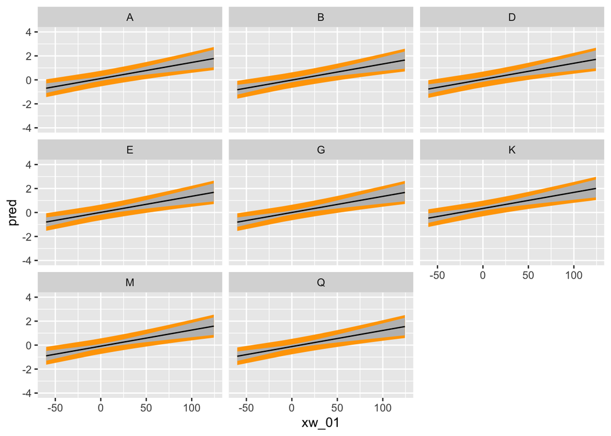

```r
pred_lm_best %>%
  ggplot(mapping=aes(x=xw_01))+
  geom_ribbon(mapping=aes(ymin=pred_lwr,ymax=pred_upr),fill='orange')+
  geom_ribbon(mapping=aes(ymin=ci_lwr,ymax=ci_upr),fill='grey')+
  geom_line(mapping=aes(y=pred))+
  coord_cartesian(ylim=c(-4,4))+
  facet_wrap(~customer)
```

for fit_lm_8:

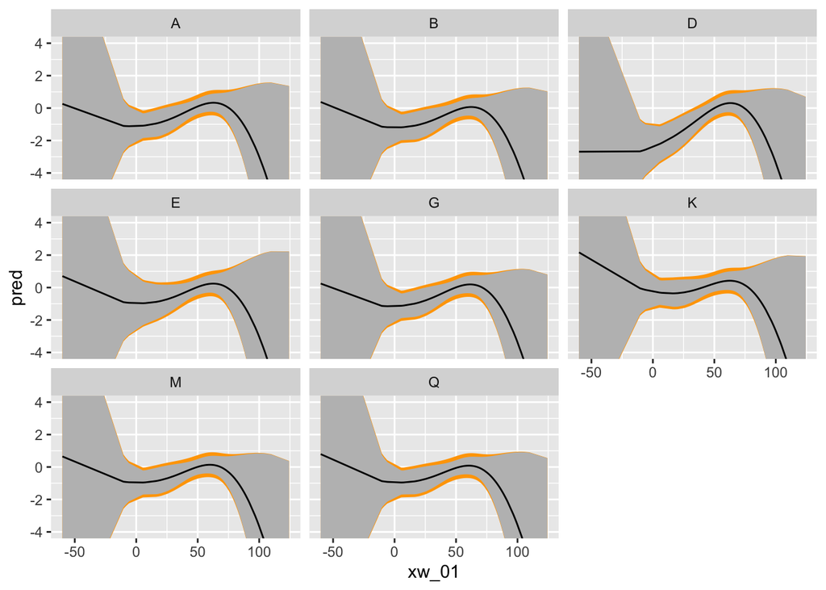

```r
pred_lm_best<-tidy_predict(fit_lm_8,viz_grid)
pred_lm_best %>%
  ggplot(mapping=aes(x=xw_01))+
  geom_ribbon(mapping=aes(ymin=pred_lwr,ymax=pred_upr),fill='orange')+
  geom_ribbon(mapping=aes(ymin=ci_lwr,ymax=ci_upr),fill='grey')+
  geom_line(mapping=aes(y=pred))+
  coord_cartesian(ylim=c(-4,4))+
  facet_wrap(~customer)
```

## state if the predictive trends are consistent between two models

SOLUTION:  
Based on the figures above, the predictive trends are not consistent between the 2 selected linear models.